# Coursework_2

Harry Wright

12 November 2016

#### 1. Logistic Regression

**This question should be answered using the `Weekly` data set, which is part of the `ISLR` package. This data is similar in nature to the `Smarket` data from this chapter’s lab, except that it contains 1,089 weekly returns for 21 years, from the beginning of 1990 to the end of 2010.**

**a) Produce some numerical and graphical summaries of the Weekly data. Do there appear to be any patters?**

```r
library(ISLR)
summary(Weekly)
```

```
##       Year           Lag1               Lag2               Lag3
##  Min.   :1990   Min.   :-18.1950   Min.   :-18.1950   Min.   :-18.1950
##  1st Qu.:1995   1st Qu.: -1.1540   1st Qu.: -1.1540   1st Qu.: -1.1580
##  Median :2000   Median :  0.2410   Median :  0.2410   Median :  0.2410
##  Mean   :2000   Mean   :  0.1506   Mean   :  0.1511   Mean   :  0.1472
##  3rd Qu.:2005   3rd Qu.:  1.4050   3rd Qu.:  1.4090   3rd Qu.:  1.4090
##  Max.   :2010   Max.   : 12.0260   Max.   : 12.0260   Max.   : 12.0260
##       Lag4               Lag5              Volume
##  Min.   :-18.1950   Min.   :-18.1950   Min.   :0.08747
##  1st Qu.: -1.1580   1st Qu.: -1.1660   1st Qu.:0.33202
##  Median :  0.2380   Median :  0.2340   Median :1.00268
##  Mean   :  0.1458   Mean   :  0.1399   Mean   :1.57462
##  3rd Qu.:  1.4090   3rd Qu.:  1.4050   3rd Qu.:2.05373
##  Max.   : 12.0260   Max.   : 12.0260   Max.   :9.32821
##      Today          Direction
##  Min.   :-18.1950   Down:484
##  1st Qu.: -1.1540   Up  :605
##  Median :  0.2410
##  Mean   :  0.1499
##  3rd Qu.:  1.4050
##  Max.   : 12.0260
```

```r
cor(Weekly[,1:8])
```

```
##               Year         Lag1        Lag2        Lag3         Lag4
## Year    1.00000000 -0.032289274 -0.03339001 -0.03000649 -0.031127923
## Lag1   -0.03228927  1.000000000 -0.07485305  0.05863568 -0.071273876
## Lag2   -0.03339001 -0.074853051  1.00000000 -0.07572091  0.058381535
## Lag3   -0.03000649  0.058635682 -0.07572091  1.00000000 -0.075395865
## Lag4   -0.03112792 -0.071273876  0.05838153 -0.07539587  1.000000000
## Lag5   -0.03051910 -0.008183096 -0.07249948  0.06065717 -0.075675027
## Volume  0.84194162 -0.064951313 -0.08551314 -0.06928771 -0.061074617
## Today  -0.03245989 -0.075031842  0.05916672 -0.07124364 -0.007825873
##                Lag5      Volume        Today
## Year   -0.030519101  0.84194162 -0.032459894
## Lag1   -0.008183096 -0.06495131 -0.075031842
## Lag2   -0.072499482 -0.08551314  0.059166717
## Lag3    0.060657175 -0.06928771 -0.071243639
## Lag4   -0.075675027 -0.06107462 -0.007825873
## Lag5    1.000000000 -0.05851741  0.011012698
## Volume -0.058517414  1.00000000 -0.033077783
## Today   0.011012698 -0.03307778  1.000000000
```

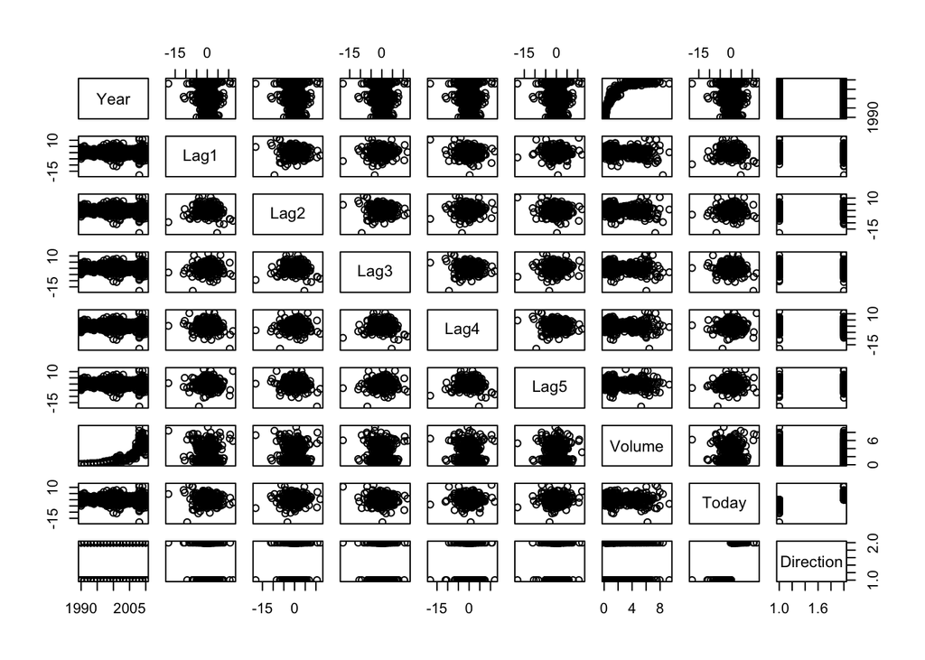

```r
pairs(Weekly)
```

There is a strong correlation between Year and Volume, it is a positive correlation.

All other correlations are close to zero.

**b) Use the full data set to perform a logistic regression with Direction as the response and the five lag variables plus Volume as predictors. Use the summary function to print the results. Do any of the predictors appear to be statistically significant? If so, which ones?**

```r
glm.fit.multi<-glm(Direction~Lag1+Lag2+Lag3+Lag4+Lag5+Volume,data=Weekly,family=binomial)
summary(glm.fit.multi)
```

```
##
## Call:
## glm(formula = Direction ~ Lag1 + Lag2 + Lag3 + Lag4 + Lag5 +
##     Volume, family = binomial, data = Weekly)
##
## Deviance Residuals:
##     Min       1Q   Median       3Q      Max
## -1.6949  -1.2565   0.9913   1.0849   1.4579
##
## Coefficients:
##             Estimate Std. Error z value Pr(>|z|)
## (Intercept)  0.26686    0.08593   3.106   0.0019 **
## Lag1        -0.04127    0.02641  -1.563   0.1181
## Lag2         0.05844    0.02686   2.175   0.0296 *
## Lag3        -0.01606    0.02666  -0.602   0.5469
## Lag4        -0.02779    0.02646  -1.050   0.2937
## Lag5        -0.01447    0.02638  -0.549   0.5833
## Volume      -0.02274    0.03690  -0.616   0.5377
## ---
## Signif. codes:  0 '***' 0.001 '**' 0.01 '*' 0.05 '.' 0.1 ' ' 1
##
## (Dispersion parameter for binomial family taken to be 1)
##
##     Null deviance: 1496.2  on 1088  degrees of freedom
## Residual deviance: 1486.4  on 1082  degrees of freedom
## AIC: 1500.4
##
## Number of Fisher Scoring iterations: 4
```

Lag2 is the only independent variable that appears to be statistically significant, with a p value at around 0.03. All other independent variables have a large p value, so are unlikely to affect the outcome.

**c) Compute the confusion matrix and overall fraction of correct predictions. Explain what the confusion matrix is telling you about the types of mistakes made by logistic regression.**

```r
glm.probs<-predict(glm.fit.multi,type="response")
glm.pred<-rep("Down",1089)
glm.pred[glm.probs>.5]<-"Up"
table(glm.pred,Weekly$Direction)
```

```
##
## glm.pred Down  Up
##     Down   54  48
##     Up    430 557
```

We can use the above results to calculate the overall fraction of correct predictions:

```r
(54+557)/1089
```

```
## [1] 0.5610652
```

Therefore the percentage of correct predictions is 56.1%, which is pretty low.

It is interesting to observe that in weeks when the Direction goes up, the prediction is correct `(557/(48+557))` = 92% of the time. However, in weeks when the Direction goes down, we are only correct `(54/(54+430))` = 11.1% of the time.

This is telling us that the model is predicting UP most of the time, and is therefore a bad model.

#### 2. Logistic Regression

**In this problem, you will develop a model to predict whether a given car gets high or low gas mileage based on the `Auto` data set.**

**a) Create a binary variable, `mpg01`, that contains a 1 if mpg contains a value above its median, and a 0 if mpg contains a value below its median. You can compute the median using the median() function. Note you may find it helpful to use the data.frame() function to create a single data set containing both `mpg01` and the other Auto variables.**

```r
attach(Auto)
mpg01<-rep(0,nrow(Auto))
mpg01[mpg > median(mpg)]<-1
Auto<-data.frame(Auto,mpg01)
Auto[20:30,]
```

```
##    mpg cylinders displacement horsepower weight acceleration year origin
## 20  26         4           97         46   1835         20.5   70      2
## 21  25         4          110         87   2672         17.5   70      2
## 22  24         4          107         90   2430         14.5   70      2
## 23  25         4          104         95   2375         17.5   70      2
## 24  26         4          121        113   2234         12.5   70      2
## 25  21         6          199         90   2648         15.0   70      1
## 26  10         8          360        215   4615         14.0   70      1
## 27  10         8          307        200   4376         15.0   70      1
## 28  11         8          318        210   4382         13.5   70      1
## 29   9         8          304        193   4732         18.5   70      1
## 30  27         4           97         88   2130         14.5   71      3
##                            name mpg01
## 20 volkswagen 1131 deluxe sedan     1
## 21                  peugeot 504     1
## 22                  audi 100 ls     1
## 23                     saab 99e     1
## 24                     bmw 2002     1
## 25                  amc gremlin     0
## 26                    ford f250     0
## 27                    chevy c20     0
## 28                   dodge d200     0
## 29                     hi 1200d     0
## 30                 datsun pl510     1
```

**b) Explore the data graphically in order to investigate the association between `mpg01` and the other features. Which of the other features seem most likely to be useful in predicting `mpg01`? Scatterplots and boxplots may be useful tools to answer this question. Describe your findings.**

```r
cor(Auto[,-9])[9,]
```

```
##          mpg    cylinders displacement   horsepower       weight
##    0.8369392   -0.7591939   -0.7534766   -0.6670526   -0.7577566
## acceleration         year       origin        mpg01
##    0.3468215    0.4299042    0.5136984    1.0000000
```

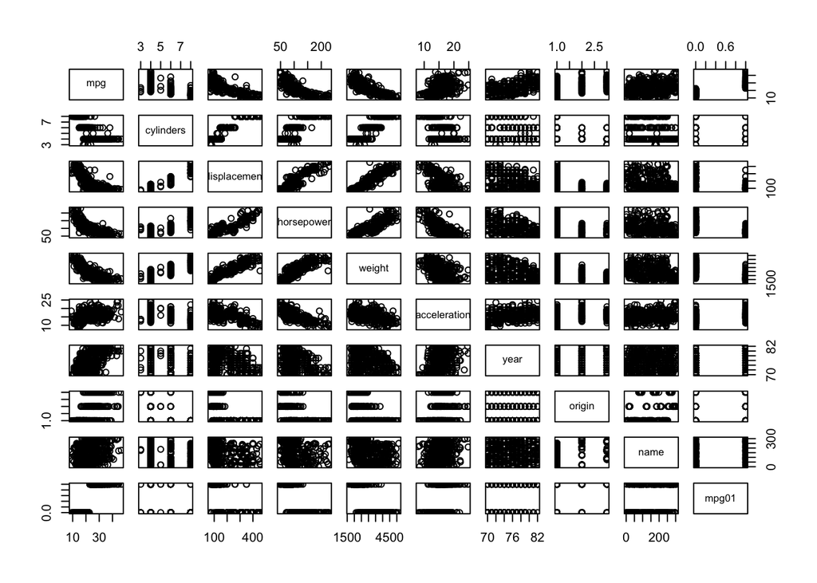

```r
pairs(Auto)
```

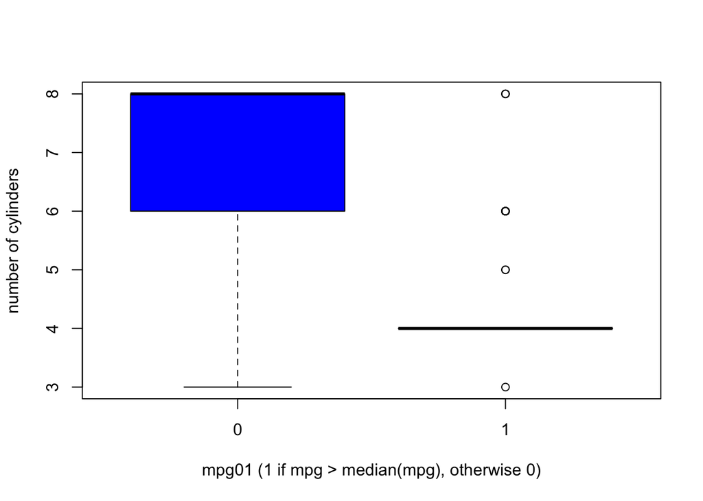

```r
boxplot(cylinders~mpg01,data=Auto,xlab="mpg01 (1 if mpg > median(mpg), otherwise 0)",ylab= "number of cylinders",col="blue")
```

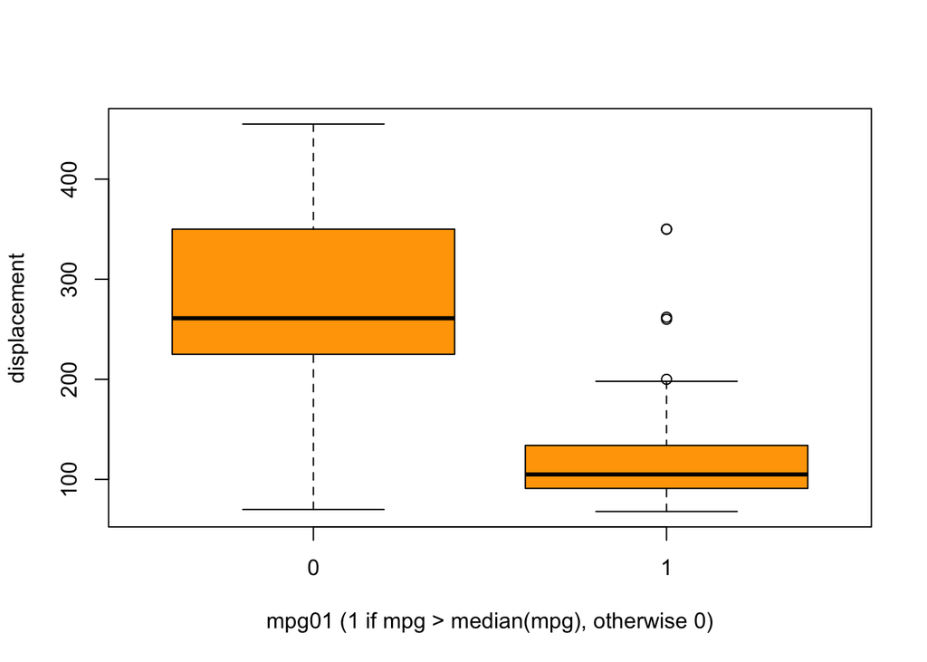

```r
boxplot(displacement~mpg01,data=Auto,xlab="mpg01 (1 if mpg > median(mpg), otherwise 0)",ylab= "displacement",col="orange")
```

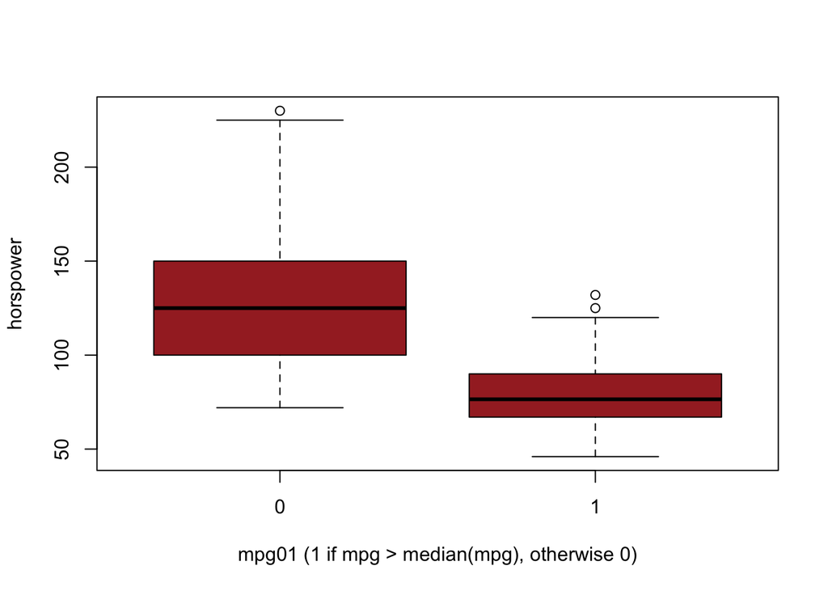

```r
boxplot(horsepower~mpg01,data=Auto,xlab="mpg01 (1 if mpg > median(mpg), otherwise 0)",ylab= "horspower",col="brown")
```

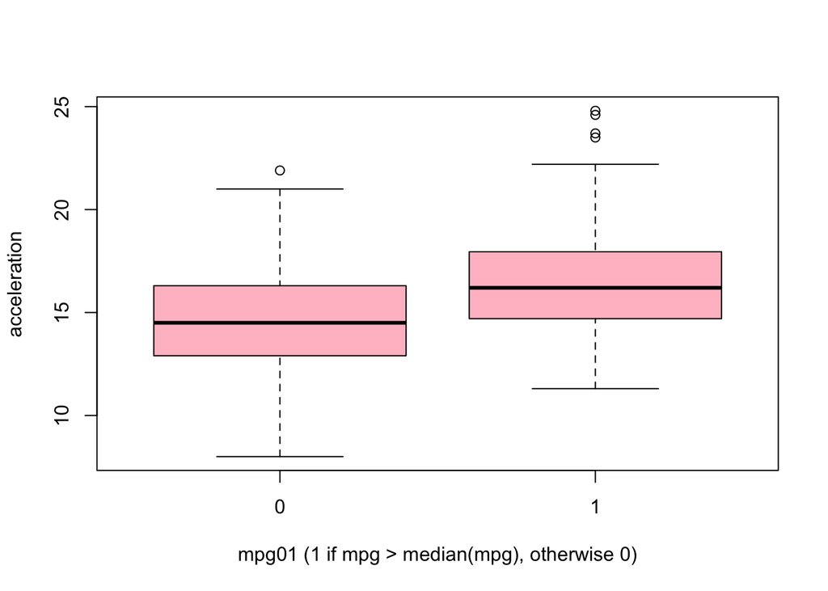

```r
boxplot(acceleration~mpg01,data=Auto,xlab="mpg01 (1 if mpg > median(mpg), otherwise 0)",ylab= "acceleration",col="pink")
```

We can see from the above that there is a strong negative correlation between (`cylinders`, `displacement`, `horsepower`) and `mpg01`. There is a small positive correlation between `Acceleration` and `mpg01`.

#### 3. Validation Set Approach

**In chapter 4, we used logistic regression to predict the probability of `default` using `income` and `balance` on the `Default` data set. We will now estimate the test error of this logistic regression model using the validation set approach. Do not forget to set a random seed before beginning your analysis.**

**a) Fit a logistic regression model that uses `income` and `balance` to predict `default`.**

```r
set.seed(1)
glm.fit.multi<-glm(default~income+balance,data=Default,family=binomial)
summary(glm.fit.multi)
```

```
##
## Call:
## glm(formula = default ~ income + balance, family = binomial,
##     data = Default)
##
## Deviance Residuals:
##     Min       1Q   Median       3Q      Max
## -2.4725  -0.1444  -0.0574  -0.0211   3.7245
##
## Coefficients:
##               Estimate Std. Error z value Pr(>|z|)
## (Intercept) -1.154e+01  4.348e-01 -26.545  < 2e-16 ***
## income       2.081e-05  4.985e-06   4.174 2.99e-05 ***
## balance      5.647e-03  2.274e-04  24.836  < 2e-16 ***
## ---
## Signif. codes:  0 '***' 0.001 '**' 0.01 '*' 0.05 '.' 0.1 ' ' 1
##
## (Dispersion parameter for binomial family taken to be 1)
##
##     Null deviance: 2920.6  on 9999  degrees of freedom
## Residual deviance: 1579.0  on 9997  degrees of freedom
## AIC: 1585
##
## Number of Fisher Scoring iterations: 8
```

**b) Using the validation set approach, estimate the test error of this model. In order to do this, you must perform the following steps:**

**i) Split the sample set into a training set and a validation set.**

```r
default.rows<-nrow(Default)
train<-sample(default.rows,default.rows/2)
```

**ii) Fit a multiple logistic regression model using only the training observations.**

```r
lm.fit.train<-glm(default~income+balance,data=Default,family=binomial,subset=train)
summary(lm.fit.train)
```

```
##
## Call:
## glm(formula = default ~ income + balance, family = binomial,
##     data = Default, subset = train)
##
## Deviance Residuals:
##     Min       1Q   Median       3Q      Max
## -2.3583  -0.1268  -0.0475  -0.0165   3.8116
##
## Coefficients:
##               Estimate Std. Error z value Pr(>|z|)
## (Intercept) -1.208e+01  6.658e-01 -18.148   <2e-16 ***
## income       1.858e-05  7.573e-06   2.454   0.0141 *
## balance      6.053e-03  3.467e-04  17.457   <2e-16 ***
## ---
## Signif. codes:  0 '***' 0.001 '**' 0.01 '*' 0.05 '.' 0.1 ' ' 1
##
## (Dispersion parameter for binomial family taken to be 1)
##
##     Null deviance: 1457.0  on 4999  degrees of freedom
## Residual deviance:  734.4  on 4997  degrees of freedom
## AIC: 740.4
##
## Number of Fisher Scoring iterations: 8
```

**iii) Obtain a prediction of default status for each individual in the validation set by computing the posterior probability of default for that individual and classifying the individual to the `default` category if the posterior probability is greater than 0.5.**

```r
glm.probs<-predict(lm.fit.train,type="response",newdata=Default[-train, ])
glm.pred<-rep("No",default.rows)
glm.pred[glm.probs>.5]<-"Yes"
```

**iv) Compute the validation set error which is the fraction of the observations in the validation set that are misclassified.**

```r
mean(glm.pred!=Default[-train,]$default)
```

```
## [1] 0.0286
```

We can see above that there is a 2.86% error rate when using the validation approach (in this circumstance)

**c) Repeat the process in (b) three times, using three different splits of the observations into a training set and validation set. Comment on the results obtained.**

```r
for(i in 1:3) {
  set.seed(i+1)
  default.rows<-nrow(Default)
  train<-sample(default.rows,default.rows/2)
  lm.fit.train<-glm(default~income+balance,data=Default,family=binomial,subset=train)
  glm.probs<-predict(lm.fit.train,type="response",newdata=Default[-train, ])
  glm.pred<-rep("No",default.rows)
  glm.pred[glm.probs>.5]<-"Yes"
  print(mean(glm.pred!=Default[-train,]$default))
}
```

```
## [1] 0.0276
## [1] 0.0248
## [1] 0.0262
```

**d) Now consider a logistic regression model that predicts the probability of `default` using `income`, `balance` and a dummy variable for `student`. Estimate the test error for this model using the validation set approach. Comment on whether or not including a dummy variable for `student` leads to a reduction in the test error rate.**

```r
set.seed(1)
train.sample<-sample(default.rows,default.rows/2)
glm.fit.train<-glm(default~income+balance+student,family=binomial,subset=train.sample,data=Default)
glm.pred<-rep("No",default.rows)
glm.probs<-predict(lm.fit.train,type="response",newdata=Default[-train.sample, ])
glm.pred[glm.probs>0.5]<-"Yes"
print(mean(glm.pred!=Default[-train.sample,]$default))
```

```
## [1] 0.0284
```

#### 4. LOOCV and Loop

**a) Fit a logistic regression model that predicts `Direction` using `Lag1` and `Lag2`.**

```r
glm.fit<-glm(Direction~Lag1+Lag2,data=Weekly,family=binomial)
summary(glm.fit)
```

```
##
## Call:
## glm(formula = Direction ~ Lag1 + Lag2, family = binomial, data = Weekly)
##
## Deviance Residuals:
##    Min      1Q  Median      3Q     Max
## -1.623  -1.261   1.001   1.083   1.506
##
## Coefficients:
##             Estimate Std. Error z value Pr(>|z|)
## (Intercept)  0.22122    0.06147   3.599 0.000319 ***
## Lag1        -0.03872    0.02622  -1.477 0.139672
## Lag2         0.06025    0.02655   2.270 0.023232 *
## ---
## Signif. codes:  0 '***' 0.001 '**' 0.01 '*' 0.05 '.' 0.1 ' ' 1
##
## (Dispersion parameter for binomial family taken to be 1)
##
##     Null deviance: 1496.2  on 1088  degrees of freedom
## Residual deviance: 1488.2  on 1086  degrees of freedom
## AIC: 1494.2
##
## Number of Fisher Scoring iterations: 4
```

**b) Fit a logistic regression model that predicts `Direction` using `Lag1` and `Lag2` using all but the first observation.**.

```r
glm.fit.except_first<-glm(Direction~Lag1+Lag2,data=Weekly[-1,],family=binomial)
summary(glm.fit.except_first)
```

```
##
## Call:
## glm(formula = Direction ~ Lag1 + Lag2, family = binomial, data = Weekly[-1,
##     ])
##
## Deviance Residuals:
##     Min       1Q   Median       3Q      Max
## -1.6258  -1.2617   0.9999   1.0819   1.5071
##
## Coefficients:
##             Estimate Std. Error z value Pr(>|z|)
## (Intercept)  0.22324    0.06150   3.630 0.000283 ***
## Lag1        -0.03843    0.02622  -1.466 0.142683
## Lag2         0.06085    0.02656   2.291 0.021971 *
## ---
## Signif. codes:  0 '***' 0.001 '**' 0.01 '*' 0.05 '.' 0.1 ' ' 1
##
## (Dispersion parameter for binomial family taken to be 1)
##
##     Null deviance: 1494.6  on 1087  degrees of freedom
## Residual deviance: 1486.5  on 1085  degrees of freedom
## AIC: 1492.5
##
## Number of Fisher Scoring iterations: 4
```

**c) Use the model from b) to predict the direction of the first observation. You can do this by predicting that the first prediction will go up if P(Direction=“Up”|Lag1,Lag2) > .5. Was this observation predicted correctly?.**

```r
predict.glm(glm.fit.except_first,type="response",newdata=Weekly[1,]) > 0.5
```

```
##    1
## TRUE
```

We can see from above that the prediction was up, however this is incorrect as the actual Direction is down.

**d) Write a for loop from i=1 to i=n, where n is the number of observations in the data set, that performs each of the following steps:**

See below.

**i) Fit a logistic regression model using all but the ith observation to predict `Direction` using `Lag1` and `Lag2`.**

See below.

**ii) Compute the posterior probability for the ith observation in order to predict whether or not the market moves up.**

See below

**iii) Use the posterior probability for the ith observation in order to predict whether or not the market moves up.**

See below.

**iv) Determine whether or not an error was made in predicting the direction for the ith observation. If an error was made, then indicate this as a 1, and otherwise indicate it as a 0.**

See below.

**e) Take the average of the n numbers obtained in d)iv) in order to obtain the LOOCV estimate for the test error. Comment on the results.**

```r
errors=rep(0,nrow(Weekly))
for(i in 1:nrow(Weekly)) {
  glm.fit.except_ith<-glm(Direction~Lag1+Lag2,data=Weekly[-i,],family=binomial)
  ith_prob<-predict.glm(glm.fit.except_ith,type="response",newdata=Weekly[i,])
  ith_pred<-ith_prob > .5
  ith_val<-Weekly[i,]$Direction == "Up"
  if(ith_pred != ith_val) errors[i] = 1
}
mean(errors)
```

```
## [1] 0.4499541
```

The error rate when using the LOOCV method is quite high at roughly 45%.

**5. We will now perform cross-validation on a simulated data set.**

**a) Generate a simulated data set as follows. In this data set, what is n and what is p? Write out the model used to generate the data in equation form.**

```r
set.seed(1)
x<-rnorm(100)
y<-x-2*x^2+rnorm(100)
```

n is 100 and p is 1.

**b) Create a scatterplot of X against Y. Comment on what you find**

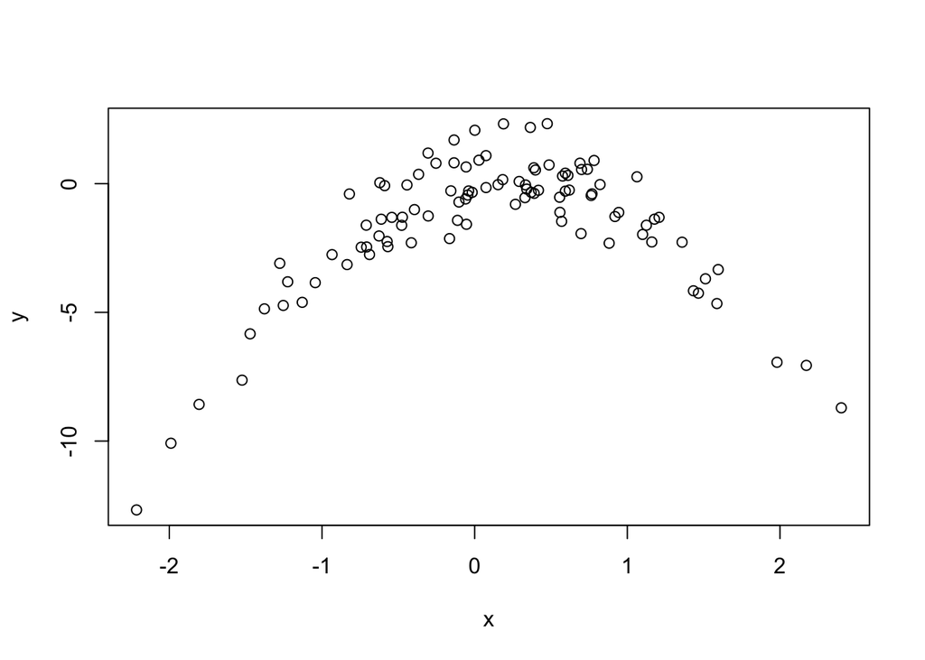

```r
plot(x,y)
```

The plot shows a curved quadratic relationship.

**c) Set a random seed, and then compute the LOOCV errors that result from fitting the following four models using least squares:**

**i) ii) iii) iv)**

```r
library(boot)
set.seed(1)
df<-data.frame(x,y)
for(i in 1:4) {
  my.fit<-glm(y~poly(x,i),data=df)
  my.cv<-cv.glm(df,my.fit)
  print(my.cv$delta[1])
}
```

```
## [1] 7.288162
## [1] 0.9374236
## [1] 0.9566218
## [1] 0.9539049
```

**d)**

```r
set.seed(2)
for(i in 1:4) {
  my.fit<-glm(y~poly(x,i),data=df)
  my.cv<-cv.glm(df,my.fit)
  print(my.cv$delta[1])
}
```

```
## [1] 7.288162
## [1] 0.9374236
## [1] 0.9566218
## [1] 0.9539049
```

My results are the same with a different seed, this is because the functions executed do not use any kind of randomness.

**e)**

The quadratic model achieves the lowest error rate. This is expected as when we created a plot of the data originally, we could see y represented a quadratic function.

**f)**

```r
summary(my.fit)
```

```
##
## Call:
## glm(formula = y ~ poly(x, i), data = df)
##
## Deviance Residuals:
##     Min       1Q   Median       3Q      Max
## -2.0550  -0.6212  -0.1567   0.5952   2.2267
##
## Coefficients:
##              Estimate Std. Error t value Pr(>|t|)
## (Intercept)  -1.55002    0.09591 -16.162  < 2e-16 ***
## poly(x, i)1   6.18883    0.95905   6.453 4.59e-09 ***
## poly(x, i)2 -23.94830    0.95905 -24.971  < 2e-16 ***
## poly(x, i)3   0.26411    0.95905   0.275    0.784
## poly(x, i)4   1.25710    0.95905   1.311    0.193
## ---
## Signif. codes:  0 '***' 0.001 '**' 0.01 '*' 0.05 '.' 0.1 ' ' 1
##
## (Dispersion parameter for gaussian family taken to be 0.9197797)
##
##     Null deviance: 700.852  on 99  degrees of freedom
## Residual deviance:  87.379  on 95  degrees of freedom
## AIC: 282.3
##
## Number of Fisher Scoring iterations: 2
```

The summary above shows that the p-values of the 3rd and 4th degree polynomials are very high, therefore they are probably not statistically significant. The p-values for the quadratic and linear are very small, indicating statistical significance.